# MATH2319 Machine Learning - Assignment 3

(1) I hereby agree to follow any and all assignment rules and procedures as stated in Canvas for this course, MATH2319.

(2) In particular, I solemnly swear that I will not discuss/ have not discussed my assignment solutions with anyone in any way and the solutions I am submitting are my own personal work.

### Full Name: Harini Mylanahally Sannaveeranna - s3755660

```python
import warnings
```

```python
warnings.filterwarnings("ignore")
```

```python
# importing the necessary modules
import numpy as np
import pandas as pd
import matplotlib.pyplot as plt
%matplotlib inline
```

```python
# loading the dataset
df = pd.read_csv('/Users/harini/Downloads/A3_Q1_train.csv')
df_ = df.copy()
df.head()
```

|  | row_id | age | education_years | workclass | marital_status | occupation | annual_income |
| --- | --- | --- | --- | --- | --- | --- | --- |
| 0 | 1 | 48 | 14 | Local-gov | Divorced | Prof-specialty | high_income |
| 1 | 2 | 23 | 13 | Local-gov | Never-married | Prof-specialty | low_income |
| 2 | 3 | 45 | 13 | Local-gov | Never-married | Prof-specialty | low_income |
| 3 | 4 | 51 | 13 | Federal-gov | Married-civ-spouse | Exec-managerial | low_income |
| 4 | 5 | 51 | 14 | Local-gov | Married-civ-spouse | Prof-specialty | high_income |

# Part A: Data Preparation

### Task 1

Transforming the two numerical features, age and education_years, into categorical ones

```python
# The cut() method in pandas is used to categorise the continuous data of a column to various bins
# of equal width by also having a label for every bin
df['age'] = pd.cut(x= df['age'], bins= 3, labels= 'low mid high'.split(), include_lowest= True)
df['education_years'] = pd.cut(x= df['education_years'], bins= 3, labels= 'low mid high'.split(), include_lowest= True)
df_all_cat = df
```

age and education_years features are binning with the following 3 bins : low, mid, and high.

```python
# so that all the columns can be displayed
pd.set_option('display.max_columns', None)
print(df_all_cat.shape)
df_all_cat.head()
```

```
(500, 7)
```

|  | row_id | age | education_years | workclass | marital_status | occupation | annual_income |
| --- | --- | --- | --- | --- | --- | --- | --- |
| 0 | 1 | high | high | Local-gov | Divorced | Prof-specialty | high_income |
| 1 | 2 | low | high | Local-gov | Never-married | Prof-specialty | low_income |
| 2 | 3 | mid | high | Local-gov | Never-married | Prof-specialty | low_income |
| 3 | 4 | high | high | Federal-gov | Married-civ-spouse | Exec-managerial | low_income |
| 4 | 5 | high | high | Local-gov | Married-civ-spouse | Prof-specialty | high_income |

```python
# dropping the column row_id as it contains only unique values and won't add much towards our
# final model
df_all_cat.drop('row_id',axis=1,inplace=True)
```

```python
# checking if all the features indeed have just categorical features
for col in df_all_cat.columns.tolist():
    print(col + ':')
    print(df_all_cat[col].value_counts())
    print('********')
```

```
age:
mid     230
low     140
high    130
Name: age, dtype: int64
********
education_years:
high    304
mid     193
low       3
Name: education_years, dtype: int64
********
workclass:
Local-gov      225
State-gov      148
Federal-gov    127
Name: workclass, dtype: int64
********
marital_status:
Married-civ-spouse    230
Never-married         155
Divorced              115
Name: marital_status, dtype: int64
********
occupation:
Prof-specialty     224
Adm-clerical       159
Exec-managerial    117
Name: occupation, dtype: int64
********
annual_income:
low_income     320
high_income    180
Name: annual_income, dtype: int64
********
```

### Task 2

performing one-hot-encoding (OHE) on the above dataset

```python
# Machine learning algorithms can't understand data if it's a categorical descriptive feature
# So, to convert categories to numerics, we use the one-hot-encoding technique (to transform a
# categorical feature into numerous discrete features)
# we'll be using to perform one-hot-encoding is the get_dummies() method.
# One-hot-encoding has to applied to just the predictor variables and not the response variable
pd.get_dummies(df_all_cat.iloc[:,:5]) # one-hot-encoded predictor variables
```

|  | age_low | age_mid | age_high | education_years_low | education_years_mid | education_years_high | workclass_Federal-gov | workclass_Local-gov | workclass_State-gov | marital_status_Divorced | marital_status_Married-civ-spouse | marital_status_Never-married | occupation_Adm-clerical | occupation_Exec-managerial | occupation_Prof-specialty |
| --- | --- | --- | --- | --- | --- | --- | --- | --- | --- | --- | --- | --- | --- | --- | --- |
| 0 | 0 | 0 | 1 | 0 | 0 | 1 | 0 | 1 | 0 | 1 | 0 | 0 | 0 | 0 | 1 |
| 1 | 1 | 0 | 0 | 0 | 0 | 1 | 0 | 1 | 0 | 0 | 0 | 1 | 0 | 0 | 1 |
| 2 | 0 | 1 | 0 | 0 | 0 | 1 | 0 | 1 | 0 | 0 | 0 | 1 | 0 | 0 | 1 |
| 3 | 0 | 0 | 1 | 0 | 0 | 1 | 1 | 0 | 0 | 0 | 1 | 0 | 0 | 1 | 0 |
| 4 | 0 | 0 | 1 | 0 | 0 | 1 | 0 | 1 | 0 | 0 | 1 | 0 | 0 | 0 | 1 |
| ... | ... | ... | ... | ... | ... | ... | ... | ... | ... | ... | ... | ... | ... | ... | ... |
| 495 | 0 | 1 | 0 | 0 | 0 | 1 | 0 | 1 | 0 | 0 | 0 | 1 | 0 | 0 | 1 |
| 496 | 0 | 0 | 1 | 0 | 0 | 1 | 0 | 1 | 0 | 0 | 1 | 0 | 0 | 0 | 1 |
| 497 | 0 | 0 | 1 | 0 | 1 | 0 | 1 | 0 | 0 | 0 | 1 | 0 | 0 | 1 | 0 |
| 498 | 0 | 0 | 1 | 0 | 1 | 0 | 0 | 1 | 0 | 0 | 0 | 1 | 0 | 0 | 1 |
| 499 | 1 | 0 | 0 | 0 | 1 | 0 | 0 | 1 | 0 | 1 | 0 | 0 | 1 | 0 | 0 |

500 rows × 15 columns

```python
# adding the response variable to the one-hot-encoded features, thereby getting the final dataframe
dd = pd.get_dummies(df_all_cat.iloc[:,:5])
dd['annual_income'] = df_all_cat['annual_income']
df_all_cat_ohe = dd
```

```python
#checking the shape of the dataset
print(df_all_cat_ohe.shape)

#displaying first 5 rows in the dataset
df_all_cat_ohe.head()
```

```
(500, 16)
```

|  | age_low | age_mid | age_high | education_years_low | education_years_mid | education_years_high | workclass_Federal-gov | workclass_Local-gov | workclass_State-gov | marital_status_Divorced | marital_status_Married-civ-spouse | marital_status_Never-married | occupation_Adm-clerical | occupation_Exec-managerial | occupation_Prof-specialty | annual_income |
| --- | --- | --- | --- | --- | --- | --- | --- | --- | --- | --- | --- | --- | --- | --- | --- | --- |
| 0 | 0 | 0 | 1 | 0 | 0 | 1 | 0 | 1 | 0 | 1 | 0 | 0 | 0 | 0 | 1 | high_income |
| 1 | 1 | 0 | 0 | 0 | 0 | 1 | 0 | 1 | 0 | 0 | 0 | 1 | 0 | 0 | 1 | low_income |
| 2 | 0 | 1 | 0 | 0 | 0 | 1 | 0 | 1 | 0 | 0 | 0 | 1 | 0 | 0 | 1 | low_income |
| 3 | 0 | 0 | 1 | 0 | 0 | 1 | 1 | 0 | 0 | 0 | 1 | 0 | 0 | 1 | 0 | low_income |
| 4 | 0 | 0 | 1 | 0 | 0 | 1 | 0 | 1 | 0 | 0 | 1 | 0 | 0 | 0 | 1 | high_income |

# Part B: Bernoulli NB

Train a Bernoulli NB model (with default parameters) using the train data and computing its accuracy on the train data itself.

Here, the target variable/feature is "annual_income"

```python
# splitting the dataset into predictor and target variables
X = df_all_cat_ohe.iloc[:,:15]
y = df_all_cat_ohe['annual_income']

# converting the target variable into binary classes
from sklearn import preprocessing
encoder = preprocessing.LabelEncoder()
y = encoder.fit_transform(df_all_cat_ohe['annual_income'])
y = np.logical_not(y).astype(int)
```

```python
# initialising and fitting the model with the default parameters
from sklearn.naive_bayes import BernoulliNB
model_bernoulli = BernoulliNB()
model_bernoulli.fit(X, y)
```

```
BernoulliNB(alpha=1.0, binarize=0.0, class_prior=None, fit_prior=True)
```

```python
# predicting the values on the train set itself
y_pred = model_bernoulli.predict(X)

# importing accuracy metric
from sklearn.metrics import accuracy_score

# finding the model accuracy
acc_br = accuracy_score(y, y_pred)
print('Accuracy for the Bernoulli NB algorithm using the default parameters is %0.2f'%acc_br)
```

```
Accuracy for the Bernoulli NB algorithm using the default parameters is 0.83
```

# Part C: Gaussian NB

```python
# initialising and fitting the gaussian model using the default parameters
from sklearn.naive_bayes import GaussianNB
model_gaussian = GaussianNB()
model_gaussian.fit(X, y)
```

```
GaussianNB(priors=None, var_smoothing=1e-09)
```

```python
# predicting the values on the train set itself
y_pred = model_gaussian.predict(X)

# importing accuracy metric
from sklearn.metrics import accuracy_score

# finding the model accuracy
acc_gs = accuracy_score(y, y_pred)
print('Accuracy for the Gaussian NB algorithm using the default parameters is %0.2f'%acc_gs)
```

```
Accuracy for the Gaussian NB algorithm using the default parameters is 0.73
```

# Part D: Tuning your Models

### Task 1: Tuning

##### Fine-tuning the alpha parameter of the Bernoulli NB model :

We'll be taking various values for alpha and building a model by using each value as the alpha parameter for the model and calculate its accuracy. We'll store all the accuracy values in a list so that they can be used to find that alpha value which gives the best accuracy

```python
alpha = [0.001,0.01,0.1,1,10,100,200,210,230,250,270,300,1000]
accuracy_bern = []

for a in alpha:
    model_bernoulli = BernoulliNB(alpha = a)
    model_bernoulli.fit(X, y)
    y_pred = model_bernoulli.predict(X)
    acc_br = accuracy_score(y, y_pred)
    accuracy_bern.append(acc_br)

print(accuracy_bern)
```

```
[0.83, 0.83, 0.83, 0.83, 0.83, 0.832, 0.838, 0.838, 0.84, 0.838, 0.828, 0.782, 0.64]
```

##### Fine-tuning the var_smoothing parameter of the Gaussian NB model :

We'll be taking various values for the var_smoothing parameter and build a model by using each value as the var_smoothing parameter for the model and calculate its accuracy. We'll store all the accuracy values we get from the models in a list so that they can be used to find that var_smoothing parameter value which gives the best accuracy

```python
smooth = [1e-9, 1e-8, 1e-7, 1e-6, 1e-5, 1e-4, 1e-3, 1e-2, 0.1, 0.5, 1, 5, 10]
accuracy_gaus = []

for s in smooth:
    model_gaussian = GaussianNB(var_smoothing=s)
    model_gaussian.fit(X, y)
    y_pred = model_gaussian.predict(X)
    acc_gs = accuracy_score(y, y_pred)
    accuracy_gaus.append(acc_gs)

print(accuracy_gaus)
```

```
[0.728, 0.75, 0.798, 0.8, 0.812, 0.824, 0.826, 0.828, 0.83, 0.834, 0.832, 0.814, 0.64]
```

### Task 2: Plotting

###### Bernoulli NB tuning results :

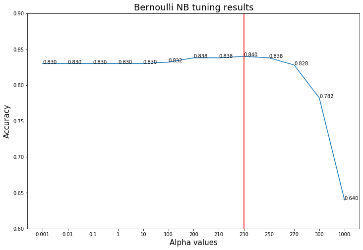

```python
plt.figure(figsize=(12,8))
plt.plot(accuracy_bern)
for i in range(13):
    plt.text(i,accuracy_bern[i],'%0.3f'%accuracy_bern[i])
plt.axvline(x=8,color = 'red')
plt.ylim(0.6,0.9)
plt.xticks(list(range(13)),labels=list(map(lambda x: str(x),alpha)))
plt.title('Bernoulli NB tuning results',fontdict={'fontsize':18})
plt.xlabel('Alpha values',fontdict={'fontsize':15})
plt.ylabel('Accuracy',fontdict={'fontsize':15})
plt.show()
```

The hyperparameter `alpha = 230` gives us the best accuracy of **0.84**

##### Gaussian NB tuning results :

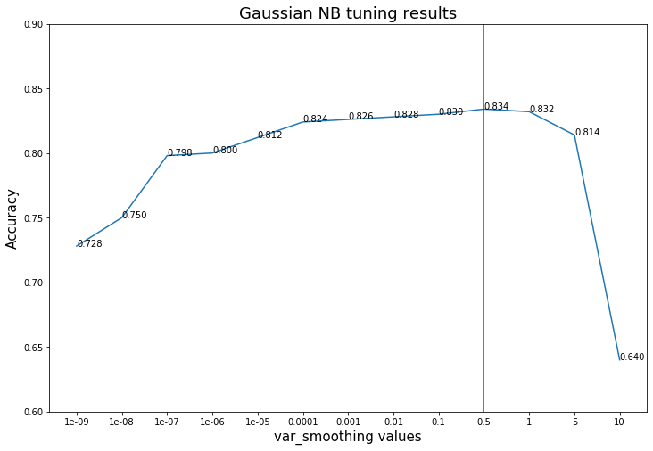

```python
plt.figure(figsize=(12,8))
plt.plot(accuracy_gaus)
for i in range(13):
    plt.text(i,accuracy_gaus[i],'%0.3f'%accuracy_gaus[i])
plt.axvline(x=9,color = 'red')
plt.ylim(0.6,0.9)
plt.xticks(list(range(13)),labels=list(map(lambda x: str(x),smooth)))
plt.title('Gaussian NB tuning results',fontdict={'fontsize':18})
plt.xlabel('var_smoothing values',fontdict={'fontsize':15})
plt.ylabel('Accuracy',fontdict={'fontsize':15})
plt.show()
```

The hyperparameter `var_smoothing = 0.5` gives us the best accuracy of **0.834**

# Part E: Hybrid NB

```python
# Using the original dataframe to build the hybrid model
df_.head()
```

|  | row_id | age | education_years | workclass | marital_status | occupation | annual_income |
| --- | --- | --- | --- | --- | --- | --- | --- |
| 0 | 1 | 48 | 14 | Local-gov | Divorced | Prof-specialty | high_income |
| 1 | 2 | 23 | 13 | Local-gov | Never-married | Prof-specialty | low_income |
| 2 | 3 | 45 | 13 | Local-gov | Never-married | Prof-specialty | low_income |
| 3 | 4 | 51 | 13 | Federal-gov | Married-civ-spouse | Exec-managerial | low_income |
| 4 | 5 | 51 | 14 | Local-gov | Married-civ-spouse | Prof-specialty | high_income |

```python
# removing the column 'row_id' as it doesn't add any pattern
df_.drop('row_id',axis=1,inplace=True)
df_.head()
```

|  | age | education_years | workclass | marital_status | occupation | annual_income |
| --- | --- | --- | --- | --- | --- | --- |
| 0 | 48 | 14 | Local-gov | Divorced | Prof-specialty | high_income |
| 1 | 23 | 13 | Local-gov | Never-married | Prof-specialty | low_income |
| 2 | 45 | 13 | Local-gov | Never-married | Prof-specialty | low_income |
| 3 | 51 | 13 | Federal-gov | Married-civ-spouse | Exec-managerial | low_income |
| 4 | 51 | 14 | Local-gov | Married-civ-spouse | Prof-specialty | high_income |

```python
# splitting the dataset into two parts, one containing numerical descriptive features to be trained
# with the Gaussian NB algorithm and the other having just categorical descriptive features to be
# trained with the Bernoulli NB algorithm
df_gs = df_[['age','education_years','annual_income']]
df_br = df_[['workclass','marital_status','occupation','annual_income']]
```

```python
# one-hot-encoding the dataset which contains categorical descriptive features
df_br_ = pd.get_dummies(df_br.iloc[:,:3])
df_br_['annual_income'] = df_br['annual_income']
df_br_.head()
```

|  | workclass_Federal-gov | workclass_Local-gov | workclass_State-gov | marital_status_Divorced | marital_status_Married-civ-spouse | marital_status_Never-married | occupation_Adm-clerical | occupation_Exec-managerial | occupation_Prof-specialty | annual_income |
| --- | --- | --- | --- | --- | --- | --- | --- | --- | --- | --- |
| 0 | 0 | 1 | 0 | 1 | 0 | 0 | 0 | 0 | 1 | high_income |
| 1 | 0 | 1 | 0 | 0 | 0 | 1 | 0 | 0 | 1 | low_income |
| 2 | 0 | 1 | 0 | 0 | 0 | 1 | 0 | 0 | 1 | low_income |
| 3 | 1 | 0 | 0 | 0 | 1 | 0 | 0 | 1 | 0 | low_income |
| 4 | 0 | 1 | 0 | 0 | 1 | 0 | 0 | 0 | 1 | high_income |

```python
# displayng first 5 rows in df_gs dataframe
df_gs.head()
```

|  | age | education_years | annual_income |
| --- | --- | --- | --- |
| 0 | 48 | 14 | high_income |
| 1 | 23 | 13 | low_income |
| 2 | 45 | 13 | low_income |
| 3 | 51 | 13 | low_income |
| 4 | 51 | 14 | high_income |

```python
# Splitting both the datasets into predictor and response variables
X_br = df_br_.iloc[:,:9]
X_gs = df_gs.iloc[:,:2]
```

```python
X_br
```

|  | workclass_Federal-gov | workclass_Local-gov | workclass_State-gov | marital_status_Divorced | marital_status_Married-civ-spouse | marital_status_Never-married | occupation_Adm-clerical | occupation_Exec-managerial | occupation_Prof-specialty |
| --- | --- | --- | --- | --- | --- | --- | --- | --- | --- |
| 0 | 0 | 1 | 0 | 1 | 0 | 0 | 0 | 0 | 1 |
| 1 | 0 | 1 | 0 | 0 | 0 | 1 | 0 | 0 | 1 |
| 2 | 0 | 1 | 0 | 0 | 0 | 1 | 0 | 0 | 1 |
| 3 | 1 | 0 | 0 | 0 | 1 | 0 | 0 | 1 | 0 |
| 4 | 0 | 1 | 0 | 0 | 1 | 0 | 0 | 0 | 1 |
| ... | ... | ... | ... | ... | ... | ... | ... | ... | ... |
| 495 | 0 | 1 | 0 | 0 | 0 | 1 | 0 | 0 | 1 |
| 496 | 0 | 1 | 0 | 0 | 1 | 0 | 0 | 0 | 1 |
| 497 | 1 | 0 | 0 | 0 | 1 | 0 | 0 | 1 | 0 |
| 498 | 0 | 1 | 0 | 0 | 0 | 1 | 0 | 0 | 1 |
| 499 | 0 | 1 | 0 | 1 | 0 | 0 | 1 | 0 | 0 |

500 rows × 9 columns

```python
# initialising and fitting both the models
model_br = BernoulliNB()
model_br.fit(X_br, y)

model_gs = GaussianNB()
model_gs.fit(X_gs, y)
```

```
GaussianNB(priors=None, var_smoothing=1e-09)
```

```python
# predicting the outcomes for both the models
y_pred_gs = model_gs.predict(X_gs)
y_pred_br = model_br.predict(X_br)

# Hybrid algorithms are used pretty often when we have multiple algorithms and we want to get the
# cumilative "Best" answer from all the constituent algorithms. This method is called 'Stacking'
# which is an ensemble learning technique. We'll be passing the results we get from the individual
# models(usually refereed to a level-0) to another machine learning algorithm(usually logistic
# regression in case of classification, referred to as level-1) to be trained on

# creating a new dataframe from the results of both the models to feed it to a logistic regression
# model thereby creating a "Hybrid NB" and getting the final results
y_pr = pd.concat([pd.Series(y_pred_br), pd.Series(y_pred_gs)], axis=1)


# Hybrid NB algorithm obtained by stacking both the NB algorithms at level-0 and using the Logistic
# regression algorithm at level-1 to correctly predict which of the models at level-0 are appropriate
# for a particular record
from sklearn.linear_model import LogisticRegression
model_hybrid = LogisticRegression()
model_hybrid.fit(y_pr,y)

# finding the accuracy of the Hybrid model
y_pr_hyb = model_hybrid.predict(y_pr)
acc_hybrid = accuracy_score(y,y_pr_hyb)
print('Accuracy for the Hybrid NB algorithm using default parameters for the base NB models is %0.2f'%acc_hybrid)
```

```
Accuracy for the Hybrid NB algorithm using default parameters for the base NB models is 0.82
```

# Part F: Wrapping Up

```python
# Wrapping up the assignment by providing the metrics for various algorithms
df_summary = pd.DataFrame()
df_summary['method'] = ['Bernoulli NB', 'Gaussian NB', 'Tuned Bernoulli NB', 'Tuned Gaussian NB', 'Hybrid NB']
df_summary['accuracy'] = [0.83,0.73,0.84,0.834,0.816]
df_summary
```

|  | method | accuracy |
| --- | --- | --- |
| 0 | Bernoulli NB | 0.830 |
| 1 | Gaussian NB | 0.730 |
| 2 | Tuned Bernoulli NB | 0.840 |
| 3 | Tuned Gaussian NB | 0.834 |
| 4 | Hybrid NB | 0.816 |

### Observations

- Hyper-parameter tuning did improve the accuracy for both the models, Bernoulli and Gaussian, albiet marginally for the Bernoulli NB model while the Gaussian NB model saw a substantial increase in its performance
- The Hybrid NB model has more predictive power than the untuned Gaussian NB model but marginally less predictive than the untuned Bernoulli NB model